# Project 1

Asmit Chakraborty

2022-09-22

# **Introduction**

The data set we will use in this project refers to a collection of police shooting cases collected by The Washington Post.

Variables contained within the data set include four main categories: Person, Incident, Factors, and Shooting. Within each main category, there are several subcategories.

Within the person category, the variables are Person.Name (full name of the individual or unknown if not reported), Person.Age (Age of the individual from or 0 if not reported), Person.Gender (Male, Female, or unknown), and Person.Race (either Asian, African American, White, Hispanic, Native American, Other, or Unknown.)

Within the incident category, the variable are Incident.Date.Month (month 1-12 in which the shooting occurred), Incident.Date.Day (day 1-31 in which the shooting occurred), Incident.Date.Year (Year 2015-2019 in which the shooting occurred), and Incident.Date.Full (Date in which the shooting occurred in the format year/month/day)

Within the factors category, the variables are Factors.Armed (Description of any weapon carried by the person and unknown if not reported), Factors.Mental-Illness (true if factors of mental illness were perceived and false otherwise), Factors.Threat-Level (Threat of the person as perceived, either “attack,” “undetermined,” “other,” or “unknown” if unreported), and Factors.Fleeing (details by which method the person was fleeing, “Not Fleeing” if not fleeing, and “unknown” if unreported)

Finally, within the shooting category, the variables are Shooting.Manner (either “shot” or “shot and”Tasered”), and Shooting.Body-Camera (True of body camera recorded the incident, false otherwise)

The chosen outcome variable of this report is the perceived threat level of the person. The predictors we will analyze include the person’s age, gender, and race.

[figure not shown]

[Source: istockphoto.com](https://www.istockphoto.com/photo/portrait-of-police-officer-holding-gun-isolated-on-white-gm108125647-647661)

# **Looking At The Outcome Variable**

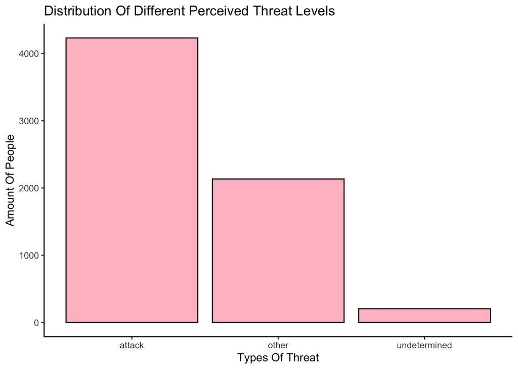

| Level Of Perceived Threat | Proportions |
| --- | --- |
| attack | 0.64 |
| other | 0.32 |
| undetermined | 0.03 |

Roughly 64% of people shot by the police were perceived as being of the “attack” level of threat. About 32% of people were perceived as being “other,” and approximately 3% were undetermined. Indeed, the majority of people shot were recognized to be aggressors who were ready to attack.

# **Looking At Each Predictor**

**Age**

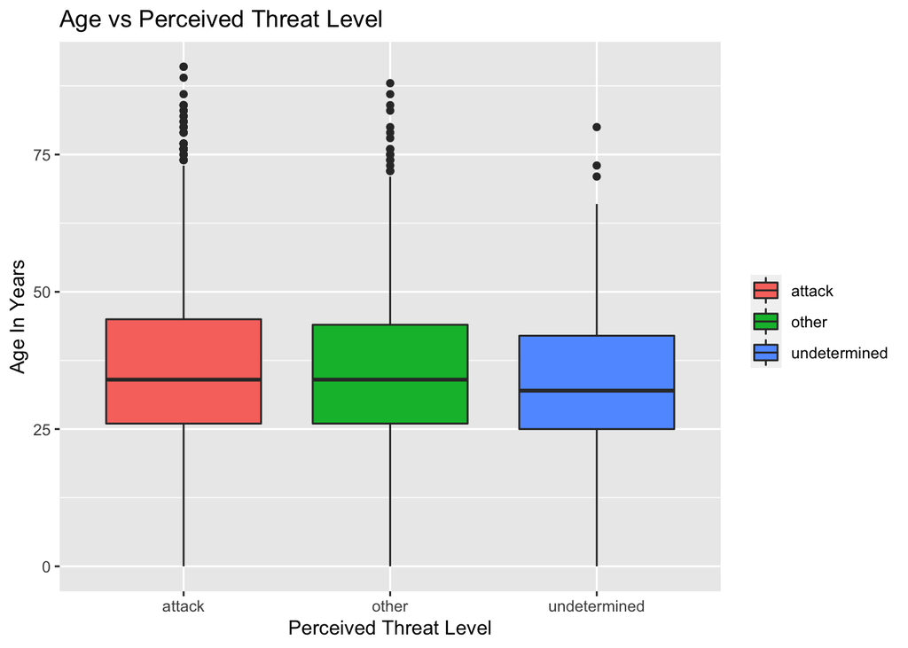

| Five Number Summary | Attack | Other | Undetermined |
| --- | --- | --- | --- |
| Minimum | 0 | 0 | 0 |
| Q1 | 26 | 26 | 25 |
| Median | 34 | 34 | 32 |
| Q3 | 45 | 44 | 42 |
| Maximum | 91 | 88 | 80 |

All three threat types have similar distributions. Although, in general, the ages of undetermined threat types tend to be slightly younger, it appears that there is no significant relationship between age and perceived threat level since all three plots are similar in spread and located around the same medians.

**Gender**

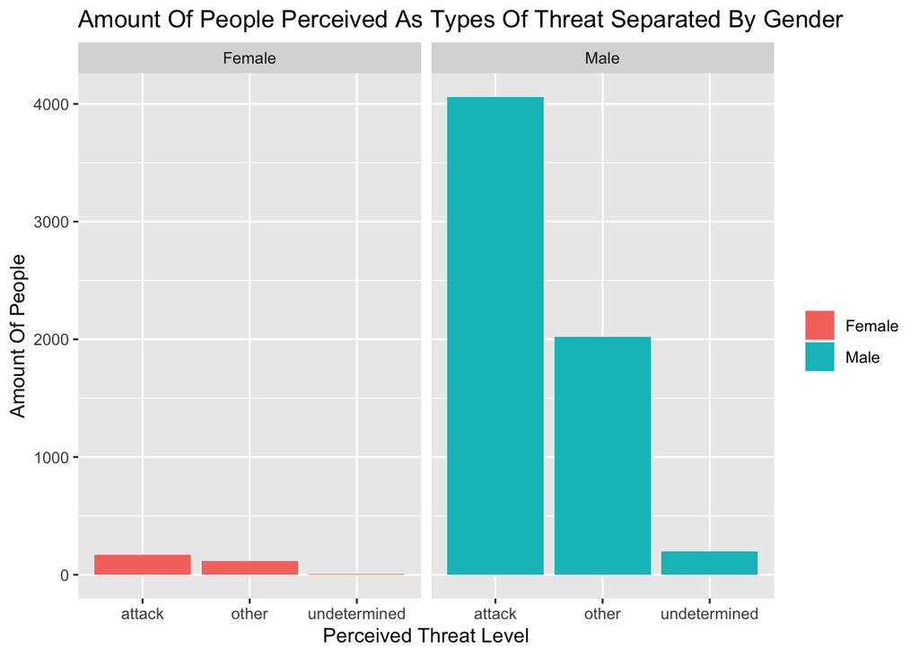

| Level Of Perceived Threat | Proportion Of Men | Proportion Of Women |
| --- | --- | --- |
| attack | 0.65 | 0.59 |
| other | 0.32 | 0.39 |
| undetermined | 0.03 | 0.02 |

**Race**

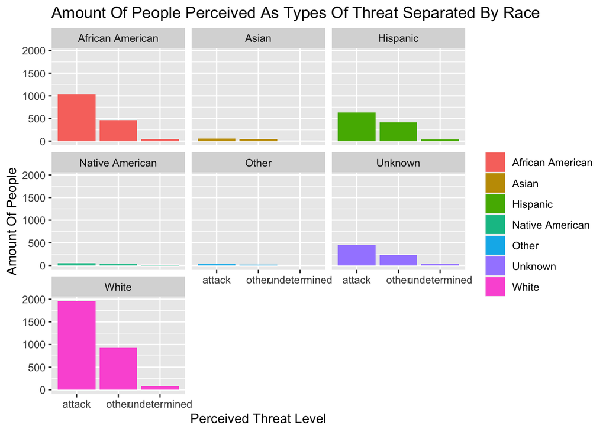

| Type | African American | Asian | Hispanic | Native American | Other | Unknown | White |
| --- | --- | --- | --- | --- | --- | --- | --- |
| attack | 0.67 | 0.53 | 0.59 | 0.58 | 0.66 | 0.63 | 0.66 |
| other | 0.30 | 0.46 | 0.38 | 0.36 | 0.34 | 0.31 | 0.31 |
| undetermined | 0.03 | 0.01 | 0.03 | 0.05 | 0.00 | 0.06 | 0.03 |

Most groups had similar proportions of people perceived as “attack,” “other,” or “undetermined.” However, there is a noticeable difference that African American people had the highest proportion (0.67) of people perceived as “attack,” and Asian people had the lowest proportion of people perceived the same (0.53). Moreover, White people and those whose race was classified as other or unknown had similar proportions to African American people, whereas those who were classified as Hispanic or Native American had similar proportions to Asian people. People with an Unknown race also had the highest proportion of people with an undetermined threat level.